# DATA 624_Exercises_HA 6.2

Jeremy O’Brien

September 7, 2019

```r
if (!require('fpp2')) (install.packages('fpp2'))
if (!require('magrittr')) (install.packages('magrittr'))
if (!require('dplyr')) (install.packages('dplyr'))
if (!require('readxl')) (install.packages('readxl'))
if (!require('RCurl')) (install.packages('RCurl'))
if (!require('tsfeatures')) (install.packages('tsfeatures'))
```

###Exercise 6.9.2 ####The *plastics* dataset consists of the monthly sales (in thousands) of product A for a plastics manufacturer for five years.

```r
help(plastics)
str(plastics)
```

####a. Plot the time series of sales of product A. Can you identify seasonal fluctuations and/or a trend-cycle?

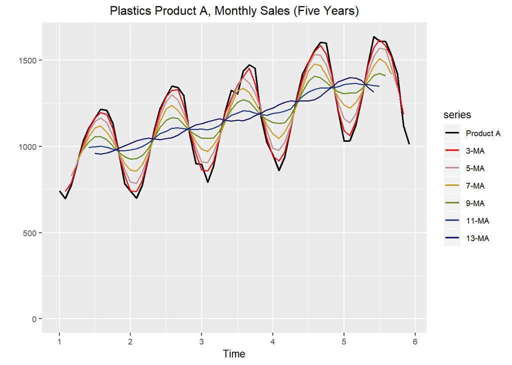

```r
# Set consistent formatting for plots
formatting <- theme(plot.title = element_text(hjust = .5)) +
  theme(text = element_text(size = 10))

# Plot the monthly plastics time series together with moving averages of order 3, 5, 7, 9, 11, and 13
autoplot(plastics, main = 'Plastics Product A, Monthly Sales (Five Years)', series = 'Product A', size = .8) +
  autolayer(ma(plastics, order = 3),
            series = '3-MA',
            size = .7) +
  autolayer(ma(plastics, order = 5),
            series = '5-MA',
            size = .7) +
  autolayer(ma(plastics, order = 7),
            series = '7-MA',
            size = .7) +
  autolayer(ma(plastics, order = 9),
            series = '9-MA',
            size = .7) +
  autolayer(ma(plastics, order = 11),
            series = '11-MA',
            size = .7) +
  autolayer(ma(plastics, order = 13),
            series = '13-MA',
            size = .7) +
  formatting +
  ylab(label = '') +
  ylim(0, max(plastics)) +
  scale_color_manual(values = c('Product A' = 'black',
                                '3-MA' = 'red',
                                '5-MA' = 'rosybrown',
                                '7-MA' = 'goldenrod3',
                                '9-MA' = 'olivedrab',
                                '11-MA' = 'royalblue4',
                                '13-MA' = 'midnightblue'),
                     breaks = c('Product A',
                                '3-MA',
                                '5-MA',
                                '7-MA',
                                '9-MA',
                                '11-MA',
                                '13-MA')
                     )
```

####There’s a clear seasonal fluctuation, exhibiting troughs at the beginning of each year and peaks over August through October. Additionally, there’s a consistent upward trend.

####b. Use a classical multiplicative decomposition to calculate the trend cycle and seasonal indices.

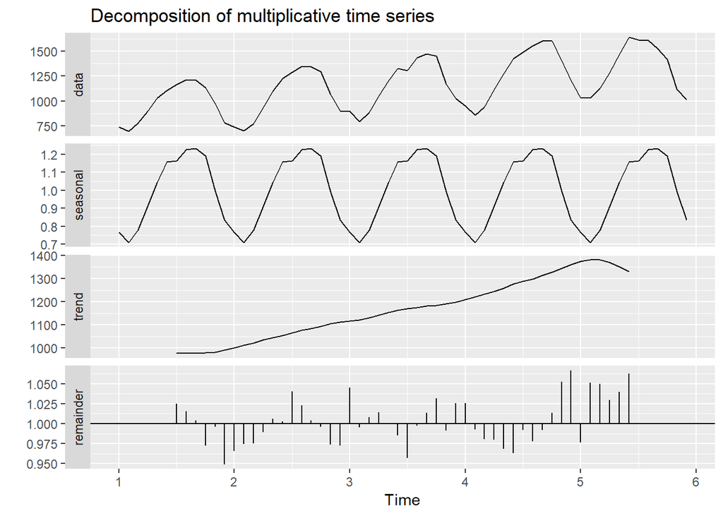

```r
# Produce multiplicative decomposition of the monthly plastics time series
plastics_decomp <- plastics %>%
  decompose(type = 'multiplicative')

# Plot the multiplicative decomposition
plastics_decomp %>%
  autoplot()
```

```r
# Output the seasonal index
(function(x) print(paste(min(x), max(x))) ) (plastics_decomp$figure)
```

```
## [1] "0.710335708434527 1.23136353496152"
```

```r
# The tsfeatures package provides statistics on strength of trend and seasonality, which doesn't seem to be a built-in feature of the forecast or other time series packages: https://rdrr.io/github/robjhyndman/tsfeatures/man/stl_features.html

# Output the trend strength and seasonal strength metrics
plastics %>%
  tsfeatures() %>%
  select(trend, seasonal_strength) %>%
  rename(trend_str = trend, season_str = seasonal_strength)
```

```
## # A tibble: 1 x 2
##   trend_str season_str
##       <dbl>      <dbl>
## 1     0.919      0.964
```

####c. Do the results support the graphical interpretations from part a?